# R Notebook

## Preliminaries

### Installing github libraries

To use **spatmap**, you must install it directly from github. This is best done with `install_github` from the ** remotes** package. We will also need to do the for **rgeoda** and **geodaData**. **rgeoda** does all of the statistical computation behind **spatmap** visualizations. **geodaData** gives us the data for this vignette.

`r`r remotes::install_github(/spatmap) remotes::install_github(/geodaData) remote::install_github(/rgeoda)

### Loading the libraries

To load the libraries we use `library`. If there is a library that is not installed, use `install.packages`. This function will work for libraries we did not remote install from github because these packages have been uploaded to CRAN.

`r`r library(spatmap) library(sf)

`r`r library(tmap) library(geodaData) library(rgeoda) library(tidyverse)

### Loading the Data

The dataset is from a classic social science study by Andre-Michel Guerry on crime, suicide , and other “moral” statistics. It is available on the GeoDa website. The spatial resolution is the prefecture-level, which is similar to the county-level. Each polygon has measures for different “moral” statistics of the area. There is some degree of temporal resolution with averages of the variables pertaining to different sets of years. These years range from 1815 to 1834. There are 23 variables in the dataset, and 85 observations. I will only be using a few of these variables for the project vignette. It can be loaded directly from **geodaData**.

`r`r guerry <- geodaData::guerry

### Creating custom weights

In order to demonstarte the custom weights option of the mapping functions in **spatmap**, we will create some weights with **rgeoda**. The default option for weights is 1st order queen contiguity in the mapping functions. We will generate some rook contiguity weights to demonstrate the custom weight option.

First, we need to convert the **sf** object to **geoda**. We use `sf_to_geoda` to do this. To create rook contiguity weights, we use `rook_weights` on **guerry_gda**. This will give us weights of the **rgeoda** data structure.

`r`r guerry_gda <- sf_to_geoda(guerry) rook <- rook_weights(guerry_gda, order = 2)

## Mapping functions

### Local Moran Map

To make a local moran map, we use `moran_map`. The parameters are an sf data frame and the name of the variable. In our case this is **guerry**, and `"Donatns"`. This will give us a basic local moran cluster map with 999 permutations and a significance cutoff level of .05. These will be the default parameters for all of the mapping functions in **spatmap**.

`r`r moran_map(guerry, )

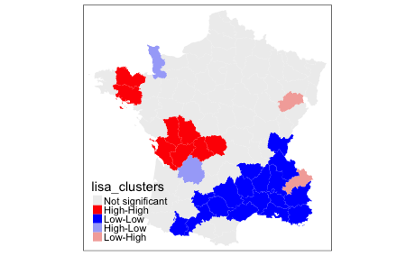

To make the corresponding significance map, we use `significance_map`. The parameters are the same as `moran_map`, but we have to also specify the type local spatial statistic. In this case it is `"moran"`.

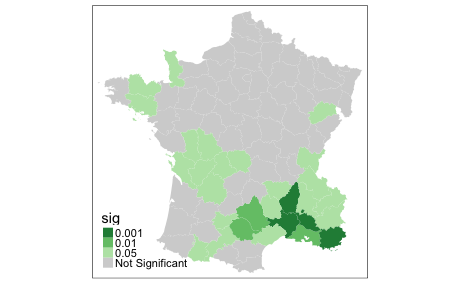

#### Permuations and Significance

##### Changing the number of permuations

To change the number of permutations in a map, we use the parameter `permutations =`. The default is 999 for every mapping function in **spatmap**. Below we set it equal to 99999.

`r`r moran_map(guerry, , permutations = 99999)

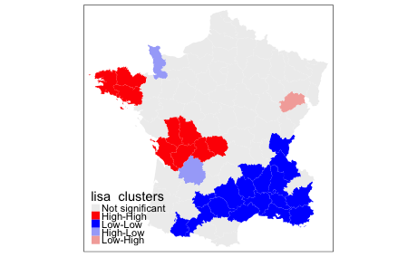

The process for changing the number of permutations is the same for `significance_map`, we just set `permutation = 99999`.

`r`r significance_map(guerry,,type = , permutations = 99999)

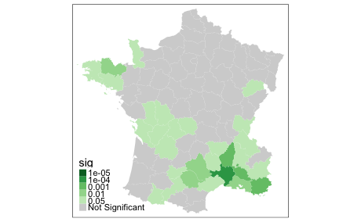

##### Changing the Significance Cutoff

To change the significance cutoff level, we use `alpha =`. Here we will change it to .01.

`r`r moran_map(guerry, , permutations = 99999, alpha = .01)

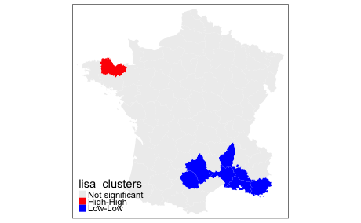

The process is the same for `significance_map`, we set `alpha = .01`.

`r`r significance_map(guerry,,type = , permutations = 99999, alpha = .01)

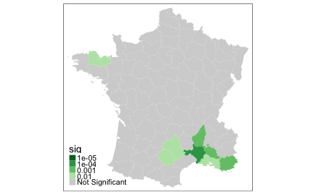

#### tmap styling options

One of the main advantages of **spatmap** is that it integrates with the **tmap** mapping package. The mapping functions allow you to add addtional layers to the map, give a vast array of formating options. To start, we set `tmap_mode("view")` to get interactive maps. We add borders to the map with `tm_borders`. We set the style with `tm_style("cobalt")`. Lastly we set the title of the map with `tm_layout`

`r`r tmap_mode()

```
tmap mode set to interactive viewing
```

`r`r moran_map(guerry, , permutations = 99999) + tm_borders() + tm_style() + tm_layout(title = Moran Map of Donatns)

We set the same styling options for the significance map as well, but with a different title.

`r`r significance_map(guerry,,type = , permutations = 99999) + tm_borders() + tm_style() + tm_layout(legend.outside = TRUE, title = Moran Significance Map )

#### Custom weights

All of the mapping functions have a parameter for custom weights, which is always `weights =`. The default option is NULL and the function computes 1st order queen contiguity weights. We can specify the custom weights to be something else, by building different wight with **rgeoda**. Earlier in the notebook, we constructed 2nd order rook contiguity weights. We use these weights in the `moran_map` with `weights =` parameter.

`r`r moran_map(guerry, , permutations = 99999, weights = rook) + tm_borders() + tm_style() + tm_layout(title = Moran Map of Donatns)

[figure not shown]

As we can see the resulting map is very different from the default weights.

To make the corresponding significance map with these weights, we use the same parameter as with the local moran map above. We set `weights = rook`.

`r`r significance_map(guerry,,type = , permutations = 99999, weights = rook) + tm_borders() + tm_style() + tm_layout(title = Moran Significance Map )

[figure not shown]

### Local Geary Map

To make the local geary cluster map, we use `geary_map`. This function has the same parameters and default options as `moran_map` with 999 permutations, a cutoff significance level of .05, and a custom weights options. We can also add the **tmap** formatting functions too.

`r`r geary_map(guerry,,permutations = 99999) + tm_style() + tm_borders() + tm_layout(title = Geary Cluster Map Donatns)

To make the corresponding significance map, we use `significance_map` and set `type = "geary"`.

`r`r significance_map(guerry,,type = , permutations = 99999, weights = rook) + tm_borders() + tm_style() + tm_layout(title = Geary Significance Map )

#### Multivariate Geary

We can make a multivariate local geary map with `multi_geary_map`. The difference here is that we use a vector of variable names as opposed to one variable name as in the other mapping functions of **spatmap**.

`r`r multi_geary_map(guerry,c(,), permutations = 99999, alpha = .01) + tm_borders() + tm_layout(title = Geary Cluster Map Donatns)

To make the significance map that corresponds to the multivariate geary map, we use `significance_map`, and enter a vector of variable names instead of just one. We also need to set `type = "geary"`.

`r`r significance_map(guerry,c(, ),type = , permutations = 99999, alpha = .01) + tm_style() + tm_borders() + tm_layout(title = Local Geary Significance Map Donatns)

[figure not shown]

### Local G Map

To make a Local G Cluster Map, we use `g_map`. This function has the same default parameters and formatting options as the other mapping functions in **spatmap**.

`r`r g_map(guerry,, permutation = 99999) + tm_borders() + tm_style() + tm_layout(title = G Cluster Map)

To make the significance map, we use `significance_map` and set `type = "g"`

`r`r significance_map(guerry,,type = , permutations = 99999) + tm_borders() + tm_layout(title = G Significance Map)

### Local G* Map

For the Local $G*$ Cluster Map, we use `gstar_map`.

`r`r gstar_map(guerry,, permutation = 99999) + tm_borders() + tm_style() + tm_layout(title = G Cluster Map)

For the associated significance map, we use `significance_map` and set `type = "gstar"`.

`r`r significance_map(guerry,,type = , permutations = 99999) + tm_borders() + tm_layout(title = G Significance Map)

### Local Join Count Map

The local join count is used primarily on binary variables, so we will create some for the univariate and multivariate maps. We will make both of the binary variables based on existing variables. To do this we will create them based off of the quintiles of **Donatns** and **Infants**.

To get the break for the top quintile of both variables, we use `quantile` with the variables as inputs and .8 to get the top quintile break, or 80th percentile.

`r`r doncatbreak <- quantile(guerry$Donatns, .8) infantbreak <- quantile(guerry$Infants, .8)

Next, we create two vectors to store the binary variables by using `rep` and starting with all 0 values. We use conditional indexing to assign 1 to all values that are greater than the 80th percentile break that we computed above.

`r`r n <- nrow(guerry) doncat <- rep(0,n) infcat <- rep(0,n) doncat[guerry$Donatns > doncatbreak] <- 1 infcat[guerry$Infants > infantbreak] <- 1 guerry$doncat <- doncat guerry$infcat <- infcat

We make a Local Join Count Cluster Map with `joincount_map` and use **doncat** as the input variable.

`r`r joincount_map(guerry,,permutations = 99999) + tm_borders() + tm_style() + tm_layout(title = Join Count Cluster Map doncat)

To get the corresponding significance map, we use `significance_map` and set `type = "join_count"`

`r`r significance_map(guerry,,permutations = 99999,type = _count) + tm_borders() + tm_style() + tm_layout(title = Join Count Significance Map doncat)

#### Multivariate Join Count Map

For the multivariate join count map, we use `multi_joincount_map`, and input both binary variables, **doncat** and **infcat**

`r`r multi_joincount_map(guerry,c(,),permutations = 99999) + tm_borders() + tm_layout(Local Join Count Cluster Map)

For the corresponding significance map, we use `significance_map`, and use the same input variables.

`r`r significance_map(guerry, c(,),permutations = 99999,type = _count) + tm_borders()